# Response to treatment and risk-of-recurrence in patients with breast cancer receiving neoadjuvant chemotherapy (NACT)

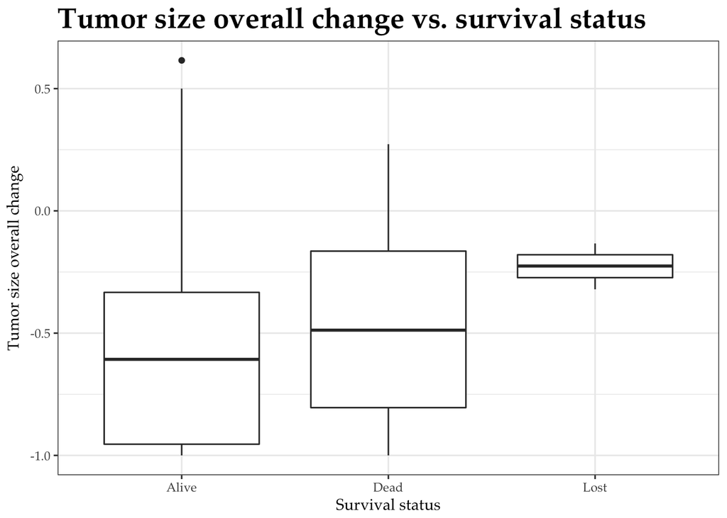

```r
ggplot(df2, aes(x=survival.status, y=overall_change)) +
  geom_boxplot() +
  theme_bw()+
  labs(title = "Tumor size overall change vs. survival status",
       x = "Survival status",
       y = "Tumor size overall change") +
  theme(
    text = element_text(family = "Palatino"),
    plot.title = element_text(hjust = 0, face="bold", size=20))
```

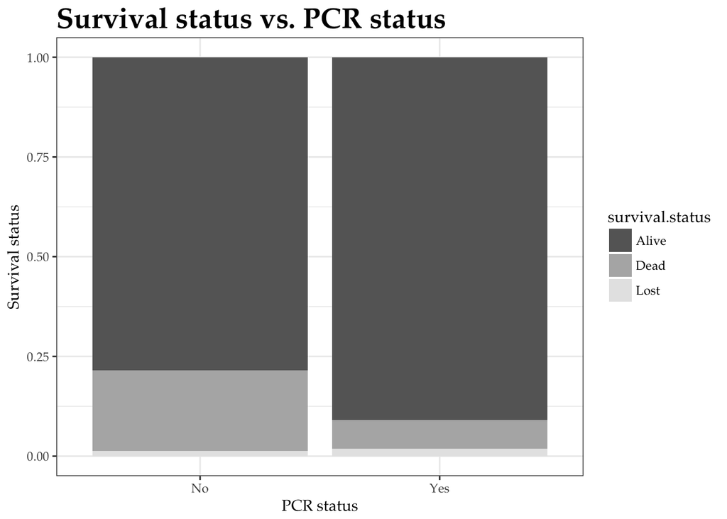

```r
ggplot(df2, aes(x=PCR, fill = survival.status)) +
  geom_bar(position="fill")+
  scale_fill_manual(values=c("gray40", "gray70", "gray90"))+
  theme_bw()+
  labs(title = "Survival status vs. PCR status",
       x = "PCR status",
       y = "Survival status") +
  theme(
    text = element_text(family = "Palatino"),
    plot.title = element_text(hjust = 0, face="bold", size=20))
```

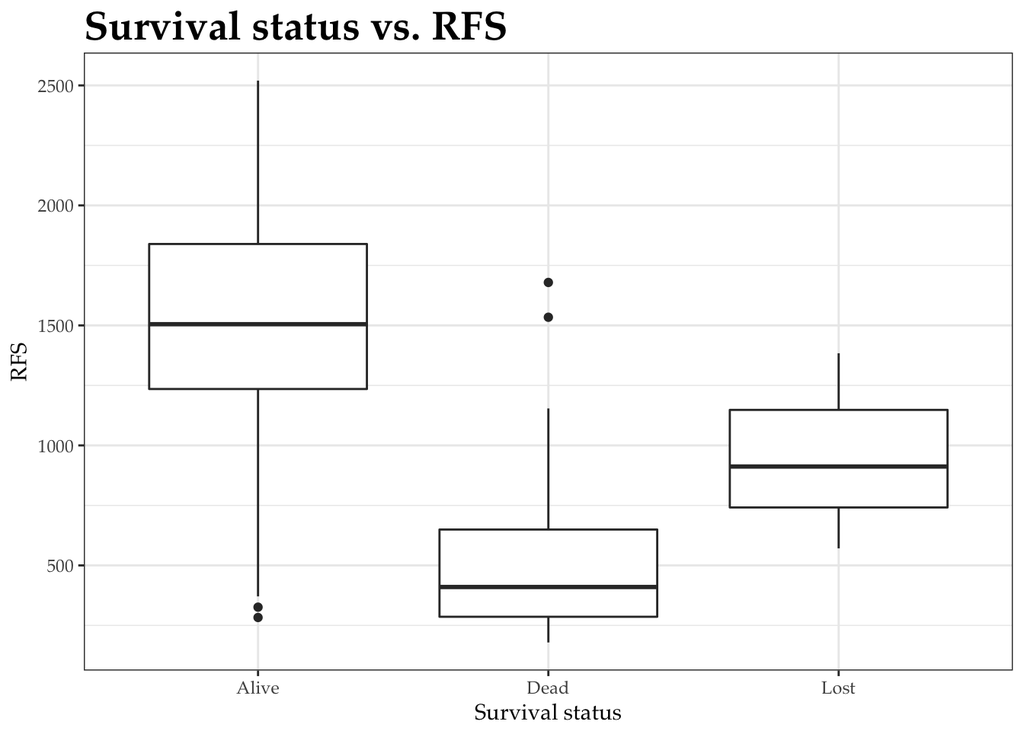

```r
ggplot(df2, aes(x=survival.status, y=RFS)) +
  geom_boxplot() +
  theme_bw()+
  labs(title = "Survival status vs. RFS",
       x = "Survival status",
       y = "RFS") +
  theme(
    text = element_text(family = "Palatino"),
    plot.title = element_text(hjust = 0, face="bold", size=20))
```

However, all previous analysis were looking at how tumor size change related to pCR, RFS and survival status regardless of the tumor type one patient have. Now I want to do a series of analysis to look at how different status of receptor, which determines the types of breast cancer, can have impact on PCR and RFS. The status of HR, HER2, ER and PR status can indicate differet types of breast cancer patients have.

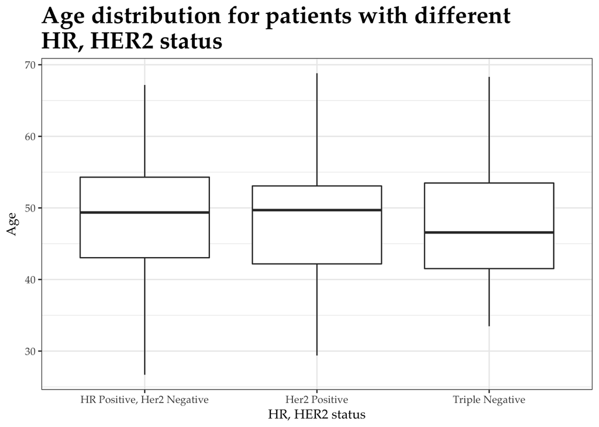

```r
ggplot(df2, aes(x=HR_HER2_CATEGORY, y=age)) +
  geom_boxplot() +
  theme_bw()+
  labs(title = "Age distribution for patients with different \nHR, HER2 status",
       x = "HR, HER2 status",
       y = "Age") +
  theme(
    text = element_text(family = "Palatino"),
    plot.title = element_text(hjust = 0, face="bold", size=20))
```

Within different tumor subsets, PCR and RFS exhibit different relationship with receptor status - HER2 positive breast cancer tends to have higher possibility to achieve positive pCR status, however, HR positive and HER2 negative breast cancer tends to have higher RFS time. The correlation of overall tumor size change with tumor subsets turns out conform to the correaltion of RFS ansd tumor subsets.

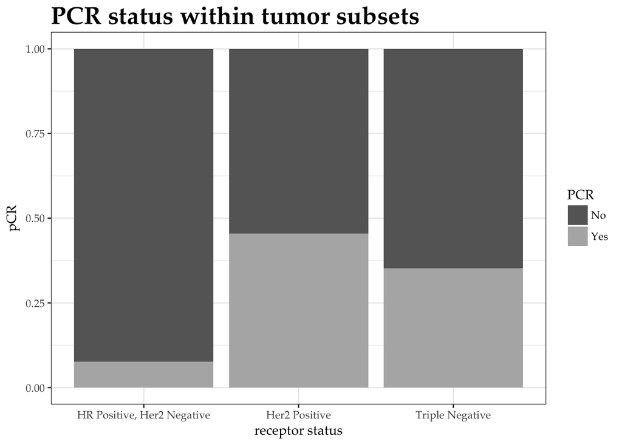

```r
ggplot(df2, aes(x=HR_HER2_CATEGORY, fill=PCR)) +
  geom_bar(position="fill") +
  scale_fill_manual(values=c("gray40", "gray70"))+
  theme_bw()+
  labs(title = "PCR status within tumor subsets",
       x = "receptor status",
       y = "pCR") +
  theme(
    text = element_text(family = "Palatino"),
    plot.title = element_text(hjust = 0, face="bold", size=20))
```

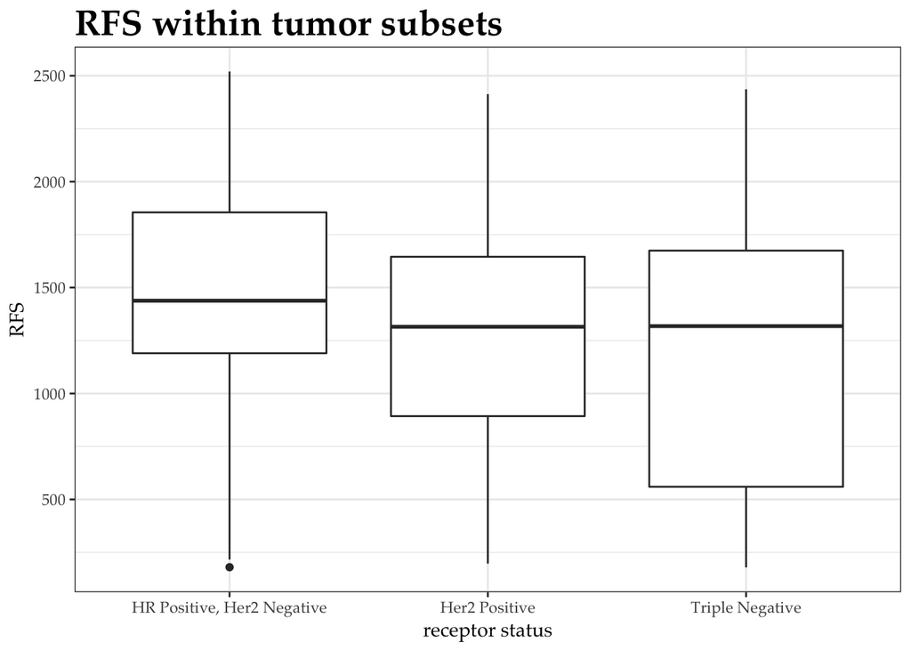

```r
ggplot(df2, aes(x=HR_HER2_CATEGORY, y=RFS)) +
  geom_boxplot() +
  theme_bw()+
  labs(title = "RFS within tumor subsets",
       x = "receptor status",
       y = "RFS") +
  theme(
    text = element_text(family = "Palatino"),
    plot.title = element_text(hjust = 0, face="bold", size=20))
```

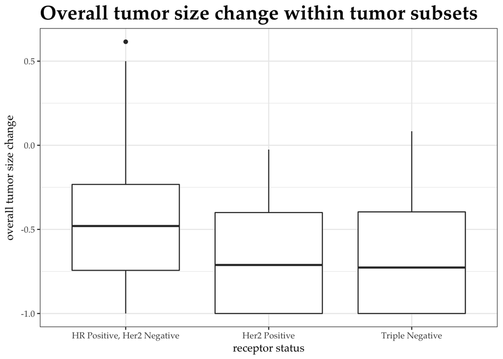

```r
ggplot(df2, aes(x=HR_HER2_CATEGORY, y=overall_change)) +
  geom_boxplot() +
  theme_bw()+
  labs(title = "Overall tumor size change within tumor subsets",
       x = "receptor status",
       y = "overall tumor size change") +
  theme(
    text = element_text(family = "Palatino"),
    plot.title = element_text(hjust = 0, face="bold", size=20))
```

Looking at the correlation between PCR and RFS, we found that patient with Pathologic Complete Response after neoadjuvant treatment will be more likely to have higher recurrence-free survival time.

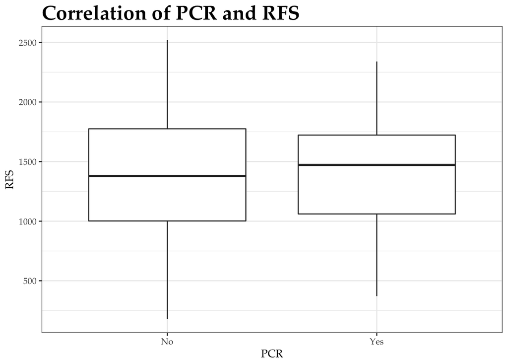

```r
ggplot(total, aes(x=PCR, y=RFS)) +
  geom_boxplot() +
  theme_bw()+
  labs(title = "Correlation of PCR and RFS",
       x = "PCR",
       y = "RFS") +
  theme(
    text = element_text(family = "Palatino"),
    plot.title = element_text(hjust = 0, face="bold", size=20))
```

To confirm the previous results, I look at the association with various receptor status and PCR,RFS outcome, a multivariate regression model is made. Based on the multivariate regression model, age and HER2 receptor status are two relatively significant predictors compared to other variables for PCR outcome, and estrogen receptor status is a relatively significant predictor compared to other variables for RFS outcome.

```r
#Create logistic regression model using all variables
PCR.glm <- glm(PCR ~ age + ERpos + PgRpos + Her2MostPos + HR_status + HR_HER2_CATEGORY + BilateralCa, data=total, family=binomial(logit))
summary(PCR.glm)
```

```
##
## Call:
## glm(formula = PCR ~ age + ERpos + PgRpos + Her2MostPos + HR_status +
##     HR_HER2_CATEGORY + BilateralCa, family = binomial(logit),
##     data = total)
##
## Deviance Residuals:
##     Min       1Q   Median       3Q      Max
## -1.5675  -0.8222  -0.3935   0.9154   2.3628
##
## Coefficients: (1 not defined because of singularities)
##                                  Estimate Std. Error z value Pr(>|z|)
## (Intercept)                       0.53738    1.20846   0.445  0.65655
## age                              -0.03958    0.02083  -1.900  0.05739 .
## ERposPositive                    14.74443  980.60663   0.015  0.98800
## PgRposPositive                   -0.25502    0.60794  -0.419  0.67487
## Her2MostPosPositive               1.74483    0.55757   3.129  0.00175 **
## HR_statusPositive               -15.65495  980.60683  -0.016  0.98726
## HR_HER2_CATEGORYHer2 Positive          NA         NA      NA       NA
## HR_HER2_CATEGORYTriple Negative   0.72979    0.72537   1.006  0.31437
## BilateralCaYes                    0.17088    1.26071   0.136  0.89218
## ---
## Signif. codes:  0 '***' 0.001 '**' 0.01 '*' 0.05 '.' 0.1 ' ' 1
##
## (Dispersion parameter for binomial family taken to be 1)
##
##     Null deviance: 240.30  on 207  degrees of freedom
## Residual deviance: 197.13  on 200  degrees of freedom
## AIC: 213.13
##
## Number of Fisher Scoring iterations: 15
```

```r
RFS.lm <- lm(RFS ~ age + ERpos + PgRpos + Her2MostPos + HR_status + HR_HER2_CATEGORY + BilateralCa, data=total)
summary(RFS.lm)
```

```
##
## Call:
## lm(formula = RFS ~ age + ERpos + PgRpos + Her2MostPos + HR_status +
##     HR_HER2_CATEGORY + BilateralCa, data = total)
##
## Residuals:
##      Min       1Q   Median       3Q      Max
## -1213.89  -337.45    21.27   396.23  1208.66
##
## Coefficients: (1 not defined because of singularities)
##                                 Estimate Std. Error t value Pr(>|t|)
## (Intercept)                     1128.462    271.573   4.155 4.81e-05 ***
## age                                4.945      4.446   1.112   0.2674
## ERposPositive                    664.587    257.198   2.584   0.0105 *
## PgRposPositive                   -16.134    128.601  -0.125   0.9003
## Her2MostPosPositive             -161.157    117.210  -1.375   0.1707
## HR_statusPositive               -528.004    304.393  -1.735   0.0843 .
## HR_HER2_CATEGORYHer2 Positive         NA         NA      NA       NA
## HR_HER2_CATEGORYTriple Negative -139.854    171.858  -0.814   0.4167
## BilateralCaYes                   238.799    287.855   0.830   0.4078
## ---
## Signif. codes:  0 '***' 0.001 '**' 0.01 '*' 0.05 '.' 0.1 ' ' 1
##
## Residual standard error: 560 on 200 degrees of freedom
## Multiple R-squared:  0.08079,    Adjusted R-squared:  0.04861
## F-statistic: 2.511 on 7 and 200 DF,  p-value: 0.01704
```

```r
SS.glm <- glm(survival.status ~ age + ERpos + PgRpos + Her2MostPos + HR_status + HR_HER2_CATEGORY + BilateralCa, data=total, family="binomial")
summary(PCR.glm)
```

```
##
## Call:
## glm(formula = PCR ~ age + ERpos + PgRpos + Her2MostPos + HR_status +
##     HR_HER2_CATEGORY + BilateralCa, family = binomial(logit),
##     data = total)
##
## Deviance Residuals:
##     Min       1Q   Median       3Q      Max
## -1.5675  -0.8222  -0.3935   0.9154   2.3628
##
## Coefficients: (1 not defined because of singularities)
##                                  Estimate Std. Error z value Pr(>|z|)
## (Intercept)                       0.53738    1.20846   0.445  0.65655
## age                              -0.03958    0.02083  -1.900  0.05739 .
## ERposPositive                    14.74443  980.60663   0.015  0.98800
## PgRposPositive                   -0.25502    0.60794  -0.419  0.67487
## Her2MostPosPositive               1.74483    0.55757   3.129  0.00175 **
## HR_statusPositive               -15.65495  980.60683  -0.016  0.98726
## HR_HER2_CATEGORYHer2 Positive          NA         NA      NA       NA
## HR_HER2_CATEGORYTriple Negative   0.72979    0.72537   1.006  0.31437
## BilateralCaYes                    0.17088    1.26071   0.136  0.89218
## ---
## Signif. codes:  0 '***' 0.001 '**' 0.01 '*' 0.05 '.' 0.1 ' ' 1
##
## (Dispersion parameter for binomial family taken to be 1)
##
##     Null deviance: 240.30  on 207  degrees of freedom
## Residual deviance: 197.13  on 200  degrees of freedom
## AIC: 213.13
##
## Number of Fisher Scoring iterations: 15
```

```r
PCR.glm.pred <- predict(PCR.glm, total, type="response")
RFS.lm.pred <- predict(RFS.lm, total, type="response")
```

```r
#Get prediction error estimate
library(boot)
PCR.cv.glm <- cv.glm(total, PCR.glm, K=10)
summary(PCR.cv.glm)
```

```
##       Length Class  Mode
## call    4    -none- call
## K       1    -none- numeric
## delta   2    -none- numeric
## seed  626    -none- numeric
```

```r
#Cross validation
N = nrow(total)
K = 10
set.seed(1234)
s = sample(1:K, size=N, replace=T)
pred_outputs.glm <- vector(mode="numeric", length=N)
obs_outputs <- vector(mode="numeric", length=N)
offset <- 0
for(i in 1:K){
    train <- filter(total, s != i)
    test <- filter(total, s == i)
    obs_outputs[1:length(s[s==i]) + offset] <- test$PCR

    #GLM train/test
    glm <- glm(PCR ~ age + ERpos + PgRpos + Her2MostPos + HR_status + HR_HER2_CATEGORY, data=train, family=binomial(logit))
    glm.pred.curr <- predict(glm, test, type="response")
    pred_outputs.glm[1:length(s[s==i]) + offset] <- glm.pred.curr
}

N = nrow(total)
K = 10
set.seed(1234)
s = sample(1:K, size=N, replace=T)
pred_outputs.lm <- vector(mode="numeric", length=N)
obs_outputs <- vector(mode="numeric", length=N)
offset <- 0
for(i in 1:K){
    train <- filter(total, s != i)
    test <- filter(total, s == i)
    obs_outputs[1:length(s[s==i]) + offset] <- test$RFS

    #GLM train/test
    lm <- lm(RFS ~ age + ERpos + PgRpos + Her2MostPos + HR_status + HR_HER2_CATEGORY, data=train, family=binomial(logit))
    lm.pred.curr <- predict(lm, test, type="response")
    pred_outputs.lm[1:length(s[s==i]) + offset] <- lm.pred.curr
}

library(pROC)
roc(total$PCR, PCR.glm.pred, ci=TRUE)
```

```
##
## Call:
## roc.default(response = total$PCR, predictor = PCR.glm.pred, ci = TRUE)
##
## Data: PCR.glm.pred in 153 controls (total$PCR No) < 55 cases (total$PCR Yes).
## Area under the curve: 0.7851
## 95% CI: 0.72-0.8503 (DeLong)
```

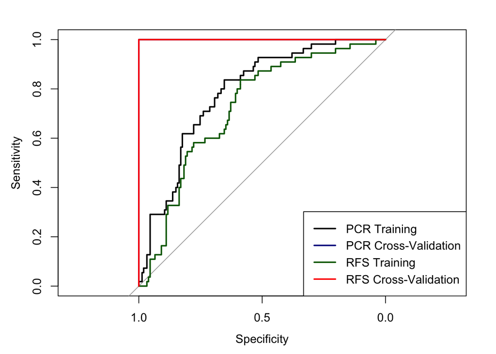

```r
plot.roc(total$PCR, PCR.glm.pred, ci=TRUE)
plot.roc(obs_outputs, pred_outputs.glm,ci=TRUE, col="darkblue", add=TRUE)
plot.roc(total$PCR, RFS.lm.pred, ci=TRUE, col="darkgreen", add=TRUE)
plot.roc(obs_outputs, pred_outputs.lm, ci=TRUE, col="red", add=TRUE)

legend("bottomright", legend=c("PCR Training", "PCR Cross-Validation", "RFS Training", "RFS Cross-Validation"), col=c("black", "darkblue", "darkgreen", "red"), lwd=2)
```

```r
auc(total$PCR, PCR.glm.pred)
```

```
## Area under the curve: 0.7851
```

```r
auc(obs_outputs, pred_outputs.glm)
```

```
## Area under the curve: 1
```

```r
auc(total$PCR, RFS.lm.pred)
```

```
## Area under the curve: 0.7232
```

```r
auc(obs_outputs, pred_outputs.lm)
```

```
## Area under the curve: 1
```

```r
#Create logistic regression model using best variables
PCR.glm <- glm(PCR ~ age +Her2MostPos, data=total, family="binomial")
summary(PCR.glm)
```

```
##
## Call:
## glm(formula = PCR ~ age + Her2MostPos, family = "binomial", data = total)
##
## Deviance Residuals:
##     Min       1Q   Median       3Q      Max
## -1.3708  -0.7105  -0.5923   1.1271   2.0843
##
## Coefficients:
##                     Estimate Std. Error z value Pr(>|z|)
## (Intercept)          0.01439    0.92553   0.016   0.9876
## age                 -0.03281    0.01926  -1.704   0.0885 .
## Her2MostPosPositive  1.39360    0.33543   4.155 3.26e-05 ***
## ---
## Signif. codes:  0 '***' 0.001 '**' 0.01 '*' 0.05 '.' 0.1 ' ' 1
##
## (Dispersion parameter for binomial family taken to be 1)
##
##     Null deviance: 240.30  on 207  degrees of freedom
## Residual deviance: 220.14  on 205  degrees of freedom
## AIC: 226.14
##
## Number of Fisher Scoring iterations: 4
```

```r
RFS.lm <- lm(RFS ~ ERpos, data=total)
summary(RFS.lm)
```

```
##
## Call:
## lm(formula = RFS ~ ERpos, data = total)
##
## Residuals:
##      Min       1Q   Median       3Q      Max
## -1240.01  -343.51    34.54   401.53  1240.04
##
## Coefficients:
##               Estimate Std. Error t value Pr(>|t|)
## (Intercept)    1195.96      59.45  20.118  < 2e-16 ***
## ERposPositive   260.05      78.59   3.309  0.00111 **
## ---
## Signif. codes:  0 '***' 0.001 '**' 0.01 '*' 0.05 '.' 0.1 ' ' 1
##
## Residual standard error: 560.8 on 206 degrees of freedom
## Multiple R-squared:  0.05046,    Adjusted R-squared:  0.04585
## F-statistic: 10.95 on 1 and 206 DF,  p-value: 0.001106
```

```r
PCR.glm.pred <- predict(PCR.glm, total, type="response")
RFS.lm.pred <- predict(RFS.lm, total, type="response")

#Get prediction error estimate
library(boot)
PCR.cv.glm <- cv.glm(total, PCR.glm, K=10)
summary(PCR.cv.glm)
```

```
##       Length Class  Mode
## call    4    -none- call
## K       1    -none- numeric
## delta   2    -none- numeric
## seed  626    -none- numeric
```

```r
#Cross validation
N = nrow(total)
K = 10
set.seed(1234)
s = sample(1:K, size=N, replace=T)
pred_outputs.glm <- vector(mode="numeric", length=N)
obs_outputs <- vector(mode="numeric", length=N)
offset <- 0
for(i in 1:K){
    train <- filter(total, s != i)
    test <- filter(total, s == i)
    obs_outputs[1:length(s[s==i]) + offset] <- test$PCR

    #GLM train/test
    glm <- glm(PCR ~ age + Her2MostPos, data=train, family=binomial(logit))
    glm.pred.curr <- predict(glm, test, type="response")
    pred_outputs.glm[1:length(s[s==i]) + offset] <- glm.pred.curr
}

N = nrow(total)
K = 10
set.seed(1234)
s = sample(1:K, size=N, replace=T)
pred_outputs.lm <- vector(mode="numeric", length=N)
obs_outputs <- vector(mode="numeric", length=N)
offset <- 0
for(i in 1:K){
    train <- filter(total, s != i)
    test <- filter(total, s == i)
    obs_outputs[1:length(s[s==i]) + offset] <- test$RFS

    #GLM train/test
    lm <- lm(RFS ~ ERpos, data=train, family=binomial(logit))
    lm.pred.curr <- predict(lm, test, type="response")
    pred_outputs.lm[1:length(s[s==i]) + offset] <- lm.pred.curr
}

library(pROC)
roc(total$PCR, PCR.glm.pred, ci=TRUE)
```

```
##
## Call:
## roc.default(response = total$PCR, predictor = PCR.glm.pred, ci = TRUE)
##
## Data: PCR.glm.pred in 153 controls (total$PCR No) < 55 cases (total$PCR Yes).
## Area under the curve: 0.715
## 95% CI: 0.639-0.791 (DeLong)
```

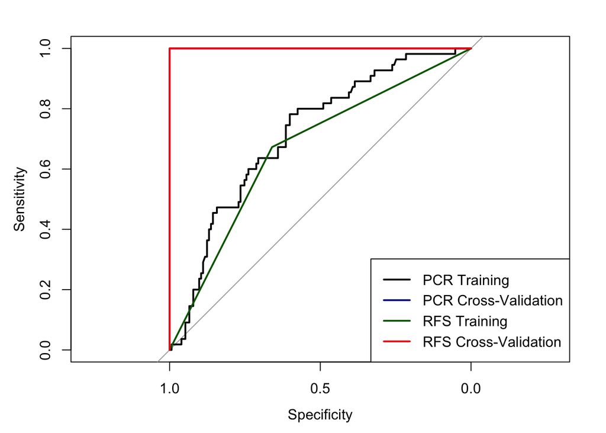

```r
plot.roc(total$PCR, PCR.glm.pred, ci=TRUE)
plot.roc(obs_outputs, pred_outputs.glm,ci=TRUE, col="darkblue", add=TRUE)
plot.roc(total$PCR, RFS.lm.pred, ci=TRUE, col="darkgreen", add=TRUE)
plot.roc(obs_outputs, pred_outputs.lm, ci=TRUE, col="red", add=TRUE)

legend("bottomright", legend=c("PCR Training", "PCR Cross-Validation", "RFS Training", "RFS Cross-Validation"), col=c("black", "darkblue", "darkgreen", "red"), lwd=2)
```

```r
auc(total$PCR, PCR.glm.pred)
```

```
## Area under the curve: 0.715
```

```r
auc(obs_outputs, pred_outputs.glm)
```

```
## Area under the curve: 1
```

```r
auc(total$PCR, RFS.lm.pred)
```

```
## Area under the curve: 0.6664
```

```r
auc(obs_outputs, pred_outputs.lm)
```

```
## Area under the curve: 1
```